# Learning from Imbalanced Data

과제내용

- Imbalanced learning 기법 간 성능 비교
- 상세내용은 아래 실험방법 참조

•데이터

- Kaggle Competition으로 2017년말에 개최되었던 "WSDM - KKBox's Music Recommendation Challenge" 데이터에 Feature Engineering을 적용한 것을 사용한다. (첨부화일)

•실험방법

- class 변수인 'target' 필드에서 1의 값이 전체 데이터의 0.1%, 1%, 10%가 되도록 축소하여 3가지의 data imbalance 상황을 만든다. (필요시 위에 더하여 새로운 imbalance 상황을 추가할 수 있음)
- 각각의 data imbalance 상황에서, 여러 Imbalanced learning 기법을 적용한 데이터에 대해 RandomForest 알고리즘을 적용하여 성능을 평가하고 비교한다. (존재하는 feature를 수정하지 않고 그대로 사용함)
- 평가척도로는 Accuracy, ROC-AUC, Recall, Precision, F1-score 등 5가지를 사용하고, "Survey of resampling techniques for improving classification performance in unbalanced datasets" 논문(첨부화일)에서 테스트한 기법 중 imbalanced-learn 패키지에서 지원하는 것은 모두 테스트한다.

•제출물

- 소스코드(화일명: 이름1-이름2.ipynb)와 결과보고서(화일명: 이름1-이름2.ppt)
- 4월22일 수업시간에 팀당 10분 이내 발표

•유의사항

- 마감시간 내에 제출한 과제만 평가함.
- 반드시, 담당교수 이메일(www4u@kookmin.ac.kr)로 제출해야 하고, 메일 제목은 "팀과제(2차) 이름1-이름2"로 할 것.

## Imbalance_Case : 1%

```python
# ! pip install -U imbalanced-learn # U 하면 새버전으로 깔림.
```

```python
import pandas as pd
import random
from sklearn.ensemble import RandomForestClassifier
from sklearn.datasets import make_classification
from sklearn.model_selection import train_test_split
from sklearn.metrics import classification_report
from sklearn.metrics import precision_score
from sklearn.metrics import recall_score
from sklearn.metrics import accuracy_score
from sklearn.metrics import roc_auc_score
from sklearn.metrics import f1_score

import numpy as np
import matplotlib.pylab as plt
%matplotlib inline
from collections import Counter
from sklearn.svm import SVC
```

```python
data = pd.read_csv("WSDM_train_full_features.csv")
```

```python
data.head()
```

|  | target | user_idx | song_idx | ssn_idx | sst_idx | st_idx | song_length | genr_idx | art_idx | com_idx | ... | lyricists_count | composer_count | is_featured | artist_count | artist_composer | artist_composer_lyricist | song_lang_boolean | smaller_song | count_song_played | count_artist_played |
| --- | --- | --- | --- | --- | --- | --- | --- | --- | --- | --- | --- | --- | --- | --- | --- | --- | --- | --- | --- | --- | --- |
| 0 | 1 | 0 | 0 | 0 | 0 | 0 | 206471 | 7 | 1877 | 7450 | ... | 0 | 2 | 0 | 0 | 0 | 0 | 0 | 1 | 215 | 1140 |
| 1 | 1 | 1 | 1 | 1 | 1 | 1 | 284584 | 18 | 92 | 2 | ... | 0 | 1 | 0 | 0 | 0 | 0 | 0 | 0 | 1 | 303616 |
| 2 | 1 | 1 | 2 | 1 | 1 | 1 | 225396 | 18 | 527 | 100234 | ... | 0 | 1 | 0 | 0 | 0 | 0 | 0 | 1 | 4 | 289 |
| 3 | 1 | 1 | 3 | 1 | 1 | 1 | 255512 | 229 | 89592 | 193180 | ... | 0 | 1 | 0 | 0 | 0 | 0 | 0 | 0 | 1 | 1 |
| 4 | 1 | 0 | 4 | 0 | 0 | 0 | 187802 | 13 | 195 | 137 | ... | 0 | 3 | 0 | 0 | 0 | 0 | 0 | 1 | 412 | 427 |

5 rows × 30 columns

```python
#data=data.iloc[0:round(len(data)/2),:]
#data.shape
```

```python
#data=data.iloc[0:round(len(data)/2),:]
#data.shape
```

```python
#data=data.iloc[0:round(len(data)/2),:]
#data.shape
```

```python
data=data.iloc[0:round(len(data)/16),:]
data.shape
```

```
(461089, 30)
```

```python
data_0 = data[data['target']==0]
data_1 = data[data['target']==1]
```

```python
print(data_0.shape[0])
print(data_1.shape[0])
```

```
124940
336149
```

```python
# Imbalance = 1%

data_1_01 = data_1.iloc[np.random.randint(0,len(data_1),size=round((1/99)*len(data_0)))]
print(data_1_01.shape)
print(data_1_01.head())
```

```
(1262, 30)
        target  user_idx  song_idx  ssn_idx  sst_idx  st_idx  song_length  \
93528        1      5686      1343        8        3       0       206007
282300       1      5951     52103        6        3       0       310613
245548       1       666      3307        1        1       2       277106
76624        1      5413     24364        2        3       1       253654
258555       1      3026     52191        1        1       1       271987

        genr_idx  art_idx  com_idx  ...  lyricists_count  composer_count  \
93528          0     2720        2  ...                0               1
282300         9    47149        2  ...                0               1
245548         0      507     2127  ...                1               1
76624          8      167    59840  ...                0               4
258555        10     3662   239737  ...                0               2

```

[output cut: 22 more lines]

```python
df = pd.concat([data_0,data_1_01],axis=0)
df.head()
df.shape
```

```
(126202, 30)
```

```python
data.shape # 원본데이터
```

```
(461089, 30)
```

```python
X = df.iloc[:,1:30]
y = df.iloc[:,0]
```

```python
# 학습/평가 데이터 분할
X_train, X_test, y_train, y_test = train_test_split(X, y, random_state=0)
X_train.shape, X_test.shape
```

```
((94651, 29), (31551, 29))
```

## SCORE 모아두기

```python
accuracy = []
roc_auc = []
f1 = []
recall = []
precision = []
```

# 1. BaseLine

```python
# 원래 데이터를 사용했을 때의 모델성능
y_pred = RandomForestClassifier(random_state=0).fit(X_train, y_train).predict(X_test)
y_proba = RandomForestClassifier(random_state=0).fit(X_train, y_train).predict_proba(X_test)[:,1]
print(' accuracy_score :', accuracy_score(y_test, y_pred), '\n' ,'roc_auc_score :',roc_auc_score(y_test, y_proba), '\n','f1_score :', f1_score(y_test, y_pred), '\n','recall_score :',recall_score(y_test, y_pred),'\n','precision_score :', precision_score(y_test, y_pred))
```

```
 accuracy_score : 0.9889702386612151
 roc_auc_score : 0.5654783286197808
 f1_score : 0.0
 recall_score : 0.0
 precision_score : 0.0
```

```python
accuracy.append(accuracy_score(y_test, y_pred))
roc_auc.append(roc_auc_score(y_test, y_proba))
f1.append(f1_score(y_test, y_pred))
recall.append(recall_score(y_test, y_pred))
precision.append(precision_score(y_test, y_pred))
```

```python
print(accuracy)
print(roc_auc )
print(f1 )
print(recall)
print(precision )
```

```
[0.9889702386612151]
[0.5654783286197808]
[0.0]
[0.0]
[0.0]
```

# Under_Sampling

# 2-1. NearMiss1.

```python
from imblearn.under_sampling import NearMiss
nm1 = NearMiss(version=1,random_state=0)
```

```python
X_resampled_nm1, y_resampled = nm1.fit_sample(X_train, y_train)
X_resampled_nm1.shape
```

```
(1840, 29)
```

```python
accuracy_score(y_test, y_pred)
```

```
0.9889702386612151
```

```python
# 합성 데이터를 추가했을 때의 모델성능
y_pred = RandomForestClassifier(random_state=0).fit(X_resampled_nm1, y_resampled).predict(X_test)
y_proba = RandomForestClassifier(random_state=0).fit(X_resampled_nm1, y_resampled).predict_proba(X_test)[:,1]
print(' accuracy_score :', accuracy_score(y_test, y_pred), '\n' ,'roc_auc_score :',roc_auc_score(y_test, y_proba), '\n','f1_score :', f1_score(y_test, y_pred), '\n','recall_score :',recall_score(y_test, y_pred),'\n','precision_score :', precision_score(y_test, y_pred))
print()
```

```
 accuracy_score : 0.06117080282716871
 roc_auc_score : 0.4565002616766531
 f1_score : 0.019788874549124723
 recall_score : 0.8742690058479532
 precision_score : 0.010007698229407237
```

```python
print(classification_report(y_test, y_pred))
```

```
              precision    recall  f1-score   support

           0       0.97      0.05      0.10     31209
           1       0.01      0.87      0.02       342

   micro avg       0.06      0.06      0.06     31551
   macro avg       0.49      0.46      0.06     31551
weighted avg       0.96      0.06      0.10     31551
```

```python
accuracy.append(accuracy_score(y_test, y_pred))
roc_auc.append(roc_auc_score(y_test, y_proba))
f1.append(f1_score(y_test, y_pred))
recall.append(recall_score(y_test, y_pred))
precision.append(precision_score(y_test, y_pred))
```

# 2-2. NearMiss2.

```python
from imblearn.under_sampling import NearMiss
nm2 = NearMiss(version=2,random_state=0)
```

```python
X_resampled_nm2, y_resampled = nm2.fit_sample(X_train, y_train)
X_resampled_nm2.shape
```

```
(1840, 29)
```

```python
# 합성 데이터를 추가했을 때의 모델성능
y_pred = RandomForestClassifier(random_state=0).fit(X_resampled_nm2, y_resampled).predict(X_test)
y_proba = RandomForestClassifier(random_state=0).fit(X_resampled_nm2, y_resampled).predict_proba(X_test)[:,1]
print(' accuracy_score :', accuracy_score(y_test, y_pred), '\n' ,'roc_auc_score :',roc_auc_score(y_test, y_proba), '\n','f1_score :', f1_score(y_test, y_pred), '\n','recall_score :',recall_score(y_test, y_pred),'\n','precision_score :', precision_score(y_test, y_pred))
```

```
 accuracy_score : 0.04900003169471649
 roc_auc_score : 0.5263993611079726
 f1_score : 0.021778111042284744
 recall_score : 0.9766081871345029
 precision_score : 0.011011836075302496
```

```python
accuracy.append(accuracy_score(y_test, y_pred))
roc_auc.append(roc_auc_score(y_test, y_proba))
f1.append(f1_score(y_test, y_pred))
recall.append(recall_score(y_test, y_pred))
precision.append(precision_score(y_test, y_pred))
```

# 2-3. NearMiss3.

```python
from imblearn.under_sampling import NearMiss
nm3 = NearMiss(version=3,random_state=0)
```

```python
X_resampled_nm3, y_resampled = nm3.fit_sample(X_train, y_train)
X_resampled_nm3.shape
```

```
(1840, 29)
```

```python
# 합성 데이터를 추가했을 때의 모델성능
y_pred = RandomForestClassifier(random_state=0).fit(X_resampled_nm3, y_resampled).predict(X_test)
y_proba = RandomForestClassifier(random_state=0).fit(X_resampled_nm3, y_resampled).predict_proba(X_test)[:,1]
print(' accuracy_score :', accuracy_score(y_test, y_pred), '\n' ,'roc_auc_score :',roc_auc_score(y_test, y_proba), '\n','f1_score :', f1_score(y_test, y_pred), '\n','recall_score :',recall_score(y_test, y_pred),'\n','precision_score :', precision_score(y_test, y_pred))
```

```
 accuracy_score : 0.577509429178156
 roc_auc_score : 0.6652813637691481
 f1_score : 0.03293673824724318
 recall_score : 0.6637426900584795
 precision_score : 0.01688736795119774
```

```python
accuracy.append(accuracy_score(y_test, y_pred))
roc_auc.append(roc_auc_score(y_test, y_proba))
f1.append(f1_score(y_test, y_pred))
recall.append(recall_score(y_test, y_pred))
precision.append(precision_score(y_test, y_pred))
```

# 3. RandomUnderSampler

```python
from imblearn.under_sampling import RandomUnderSampler
```

```python
rus = RandomUnderSampler(random_state=0)
```

```python
X_res, y_res = rus.fit_resample(X_train, y_train)
```

```python
# 합성 데이터를 추가했을 때의 모델성능
y_pred = RandomForestClassifier(random_state=0).fit(X_res, y_res).predict(X_test)
y_proba = RandomForestClassifier(random_state=0).fit(X_res, y_res).predict_proba(X_test)[:,1]
print(' accuracy_score :', accuracy_score(y_test, y_pred), '\n roc_auc_score :',roc_auc_score(y_test, y_proba), '\n f1_score :', f1_score(y_test, y_pred), '\n recall_score :',recall_score(y_test, y_pred),'\n precision_score :', precision_score(y_test, y_pred))
```

```
 accuracy_score : 0.6857785807105955
 roc_auc_score : 0.684391488884879
 f1_score : 0.03896859247770454
 recall_score : 0.5877192982456141
 precision_score : 0.020152396230198516
```

```python
accuracy.append(accuracy_score(y_test, y_pred))
roc_auc.append(roc_auc_score(y_test, y_proba))
f1.append(f1_score(y_test, y_pred))
recall.append(recall_score(y_test, y_pred))
precision.append(precision_score(y_test, y_pred))
```

# 4. Condensed Nearest Neighbor (CNN)

```python
from imblearn.under_sampling import CondensedNearestNeighbour
```

```python
cnn = CondensedNearestNeighbour(random_state=0)
```

```python
X_res, y_res = cnn.fit_resample(X_train, y_train)
```

```python
# 합성 데이터를 추가했을 때의 모델성능
y_pred = RandomForestClassifier(random_state=0).fit(X_res, y_res).predict(X_test)
y_proba = RandomForestClassifier(random_state=0).fit(X_res, y_res).predict_proba(X_test)[:,1]
print(' accuracy_score :', accuracy_score(y_test, y_pred), '\n' ,'roc_auc_score :',roc_auc_score(y_test, y_proba), '\n','f1_score :', f1_score(y_test, y_pred), '\n','recall_score :',recall_score(y_test, y_pred),'\n','precision_score :', precision_score(y_test, y_pred))
```

```
 accuracy_score : 0.9807296123736173
 roc_auc_score : 0.6571612364779316
 f1_score : 0.02564102564102564
 recall_score : 0.023391812865497075
 precision_score : 0.028368794326241134
```

```python
accuracy.append(accuracy_score(y_test, y_pred))
roc_auc.append(roc_auc_score(y_test, y_proba))
f1.append(f1_score(y_test, y_pred))
recall.append(recall_score(y_test, y_pred))
precision.append(precision_score(y_test, y_pred))
```

# 5. Edited Nearest Neighbor (ENN)

```python
from imblearn.under_sampling import EditedNearestNeighbours
```

```python
enn = EditedNearestNeighbours(random_state=0)
```

```python
X_res, y_res = enn.fit_resample(X_train, y_train)
```

```python
# 합성 데이터를 추가했을 때의 모델성능
y_pred = RandomForestClassifier(random_state=0).fit(X_res, y_res).predict(X_test)
y_proba = RandomForestClassifier(random_state=0).fit(X_res, y_res).predict_proba(X_test)[:,1]
print(' accuracy_score :', accuracy_score(y_test, y_pred), '\n roc_auc_score :',roc_auc_score(y_test, y_proba), '\n f1_score :', f1_score(y_test, y_pred), '\n recall_score :',recall_score(y_test, y_pred), '\n precision_score :', precision_score(y_test, y_pred))
```

```
 accuracy_score : 0.9889702386612151
 roc_auc_score : 0.5719632813221708
 f1_score : 0.011363636363636364
 recall_score : 0.005847953216374269
 precision_score : 0.2
```

```python
accuracy.append(accuracy_score(y_test, y_pred))
roc_auc.append(roc_auc_score(y_test, y_proba))
f1.append(f1_score(y_test, y_pred))
recall.append(recall_score(y_test, y_pred))
precision.append(precision_score(y_test, y_pred))
```

# 6. Repeated Edited Nearest Neighbor

```python
from imblearn.under_sampling import RepeatedEditedNearestNeighbours
```

```python
renn = RepeatedEditedNearestNeighbours(random_state=0)
```

```python
X_res, y_res = renn.fit_resample(X_train, y_train)
```

```python
# 합성 데이터를 추가했을 때의 모델성능
y_pred = RandomForestClassifier(random_state=0).fit(X_res, y_res).predict(X_test)
y_proba = RandomForestClassifier(random_state=0).fit(X_res, y_res).predict_proba(X_test)[:,1]
print(' accuracy_score :', accuracy_score(y_test, y_pred), '\n' ,'roc_auc_score :',roc_auc_score(y_test, y_proba), '\n','f1_score :', f1_score(y_test, y_pred), '\n','recall_score :',recall_score(y_test, y_pred),'\n','precision_score :', precision_score(y_test, y_pred))
```

```
 accuracy_score : 0.9887483756457799
 roc_auc_score : 0.5635846628437329
 f1_score : 0.0
 recall_score : 0.0
 precision_score : 0.0
```

```python
accuracy.append(accuracy_score(y_test, y_pred))
roc_auc.append(roc_auc_score(y_test, y_proba))
f1.append(f1_score(y_test, y_pred))
recall.append(recall_score(y_test, y_pred))
precision.append(precision_score(y_test, y_pred))
```

# 7. Tomek Link Removal

```python
from imblearn.under_sampling import TomekLinks
```

```python
tl = TomekLinks(random_state=0)
```

```python
X_res, y_res = tl.fit_resample(X_train, y_train)
```

```python
# 합성 데이터를 추가했을 때의 모델성능
y_pred = RandomForestClassifier(random_state=0).fit(X_res, y_res).predict(X_test)
y_proba = RandomForestClassifier(random_state=0).fit(X_res, y_res).predict_proba(X_test)[:,1]
print(' accuracy_score :', accuracy_score(y_test, y_pred), '\n' ,'roc_auc_score :',roc_auc_score(y_test, y_proba), '\n','f1_score :', f1_score(y_test, y_pred), '\n','recall_score :',recall_score(y_test, y_pred),'\n','precision_score :', precision_score(y_test, y_pred))
```

```
 accuracy_score : 0.9890019333777059
 roc_auc_score : 0.5515342796415563
 f1_score : 0.0057306590257879654
 recall_score : 0.0029239766081871343
 precision_score : 0.14285714285714285
```

```python
accuracy.append(accuracy_score(y_test, y_pred))
roc_auc.append(roc_auc_score(y_test, y_proba))
f1.append(f1_score(y_test, y_pred))
recall.append(recall_score(y_test, y_pred))
precision.append(precision_score(y_test, y_pred))
```

# Oversampling methods

# 1. Random oversampling of minority class

```python
from imblearn.over_sampling import RandomOverSampler
```

```python
ros = RandomOverSampler(random_state=0)
```

```python
X_res, y_res = ros.fit_resample(X_train, y_train)
```

```python
# 합성 데이터를 추가했을 때의 모델성능
y_pred = RandomForestClassifier(random_state=0).fit(X_res, y_res).predict(X_test)
y_proba = RandomForestClassifier(random_state=0).fit(X_res, y_res).predict_proba(X_test)[:,1]
print(' accuracy_score :', accuracy_score(y_test, y_pred), '\n' ,'roc_auc_score :',roc_auc_score(y_test, y_proba), '\n','f1_score :', f1_score(y_test, y_pred), '\n','recall_score :',recall_score(y_test, y_pred),'\n','precision_score :', precision_score(y_test, y_pred))
```

```
 accuracy_score : 0.9887483756457799
 roc_auc_score : 0.5705023236099798
 f1_score : 0.011142061281337047
 recall_score : 0.005847953216374269
 precision_score : 0.11764705882352941
```

```python
accuracy.append(accuracy_score(y_test, y_pred))
roc_auc.append(roc_auc_score(y_test, y_proba))
f1.append(f1_score(y_test, y_pred))
recall.append(recall_score(y_test, y_pred))
precision.append(precision_score(y_test, y_pred))
```

# 2. SMOTE

```python
from imblearn.over_sampling import SMOTE
```

```python
X_resampled, y_resampled = SMOTE(random_state=0).fit_resample(X_train, y_train)
```

```python
# 합성 데이터를 추가했을 때의 모델성능
y_pred = RandomForestClassifier(random_state=0).fit(X_resampled, y_resampled).predict(X_test)
y_proba = RandomForestClassifier(random_state=0).fit(X_resampled, y_resampled).predict_proba(X_test)[:,1]
print(' accuracy_score :', accuracy_score(y_test, y_pred), '\n' ,'roc_auc_score :',roc_auc_score(y_test, y_proba), '\n','f1_score :', f1_score(y_test, y_pred), '\n','recall_score :',recall_score(y_test, y_pred),'\n','precision_score :', precision_score(y_test, y_pred))
```

```
 accuracy_score : 0.9831067161104244
 roc_auc_score : 0.6310770022667399
 f1_score : 0.029143897996357013
 recall_score : 0.023391812865497075
 precision_score : 0.03864734299516908
```

```python
accuracy.append(accuracy_score(y_test, y_pred))
roc_auc.append(roc_auc_score(y_test, y_proba))
f1.append(f1_score(y_test, y_pred))
recall.append(recall_score(y_test, y_pred))
precision.append(precision_score(y_test, y_pred))
```

# 3-1. Borderline-SMOTE1

```python
from imblearn.over_sampling import BorderlineSMOTE
```

```python
X_resampled, y_resampled = BorderlineSMOTE(kind='borderline-1',random_state=0).fit_resample(X_train, y_train)
```

```python
# 합성 데이터를 추가했을 때의 모델성능
y_pred = RandomForestClassifier(random_state=0).fit(X_resampled, y_resampled).predict(X_test)
y_proba = RandomForestClassifier(random_state=0).fit(X_resampled, y_resampled).predict_proba(X_test)[:,1]
print(' accuracy_score :', accuracy_score(y_test, y_pred), '\n' ,'roc_auc_score :',roc_auc_score(y_test, y_proba), '\n','f1_score :', f1_score(y_test, y_pred), '\n','recall_score :',recall_score(y_test, y_pred),'\n','precision_score :', precision_score(y_test, y_pred))
```

```
 accuracy_score : 0.9885265126303445
 roc_auc_score : 0.5678174443232095
 f1_score : 0.0
 recall_score : 0.0
 precision_score : 0.0
```

```python
accuracy.append(accuracy_score(y_test, y_pred))
roc_auc.append(roc_auc_score(y_test, y_proba))
f1.append(f1_score(y_test, y_pred))
recall.append(recall_score(y_test, y_pred))
precision.append(precision_score(y_test, y_pred))
```

# 3-2.Borderline-SMOTE2

```python
X_resampled, y_resampled = BorderlineSMOTE(kind='borderline-2',random_state=0).fit_resample(X_train, y_train)
```

```python
# 합성 데이터를 추가했을 때의 모델성능
y_pred = RandomForestClassifier(random_state=0).fit(X_resampled, y_resampled).predict(X_test)
y_proba = RandomForestClassifier(random_state=0).fit(X_resampled, y_resampled).predict_proba(X_test)[:,1]
print(' accuracy_score :', accuracy_score(y_test, y_pred), '\n' ,'roc_auc_score :',roc_auc_score(y_test, y_proba), '\n','f1_score :', f1_score(y_test, y_pred), '\n','recall_score :',recall_score(y_test, y_pred),'\n','precision_score :', precision_score(y_test, y_pred))
```

```
 accuracy_score : 0.9883680390478907
 roc_auc_score : 0.5546082542166667
 f1_score : 0.0054200542005420045
 recall_score : 0.0029239766081871343
 precision_score : 0.037037037037037035
```

```python
accuracy.append(accuracy_score(y_test, y_pred))
roc_auc.append(roc_auc_score(y_test, y_proba))
f1.append(f1_score(y_test, y_pred))
recall.append(recall_score(y_test, y_pred))
precision.append(precision_score(y_test, y_pred))
```

# Combination methods

# 1. SMOTE + Tomek Link Removal

```python
from imblearn.combine import SMOTETomek
```

```python
smt = SMOTETomek(random_state=0)
```

```python
 X_res, y_res = smt.fit_resample(X_train, y_train)
```

```python
# 합성 데이터를 추가했을 때의 모델성능
y_pred = RandomForestClassifier(random_state=0).fit(X_res, y_res).predict(X_test)
y_proba = RandomForestClassifier(random_state=0).fit(X_res, y_res).predict_proba(X_test)[:,1]
print(' accuracy_score :', accuracy_score(y_test, y_pred), '\n' ,'roc_auc_score :',roc_auc_score(y_test, y_proba), '\n','f1_score :', f1_score(y_test, y_pred), '\n','recall_score :',recall_score(y_test, y_pred),'\n','precision_score :', precision_score(y_test, y_pred))
```

```
 accuracy_score : 0.9830433266774429
 roc_auc_score : 0.6468063174908872
 f1_score : 0.036036036036036036
 recall_score : 0.029239766081871343
 precision_score : 0.046948356807511735
```

```python
accuracy.append(accuracy_score(y_test, y_pred))
roc_auc.append(roc_auc_score(y_test, y_proba))
f1.append(f1_score(y_test, y_pred))
recall.append(recall_score(y_test, y_pred))
precision.append(precision_score(y_test, y_pred))
```

# 2. SMOTE + ENN

```python
 from imblearn.combine import SMOTEENN
```

```python
sme = SMOTEENN(random_state=42)
```

```python
X_res, y_res = sme.fit_resample(X_train, y_train)
```

```python
# 합성 데이터를 추가했을 때의 모델성능
y_pred = RandomForestClassifier(random_state=0).fit(X_res, y_res).predict(X_test)
y_proba = RandomForestClassifier(random_state=0).fit(X_res, y_res).predict_proba(X_test)[:,1]
print(' accuracy_score :', accuracy_score(y_test, y_pred), '\n' ,'roc_auc_score :',roc_auc_score(y_test, y_proba), '\n','f1_score :', f1_score(y_test, y_pred), '\n','recall_score :',recall_score(y_test, y_pred),'\n','precision_score :', precision_score(y_test, y_pred))
```

```
 accuracy_score : 0.9817755380178125
 roc_auc_score : 0.6277800450799637
 f1_score : 0.023769100169779286
 recall_score : 0.02046783625730994
 precision_score : 0.02834008097165992
```

```python
accuracy.append(accuracy_score(y_test, y_pred))
roc_auc.append(roc_auc_score(y_test, y_proba))
f1.append(f1_score(y_test, y_pred))
recall.append(recall_score(y_test, y_pred))
precision.append(precision_score(y_test, y_pred))
```

# Ensemble Methods

# 1. EasyEnsemble

```python
from imblearn.ensemble import EasyEnsemble
```

```python
ee = EasyEnsemble(random_state=0)
```

```python
X_res, y_res = ee.fit_resample(X, y)
```

```python
X_res=X_res.reshape(-1,29) # -1 행개수를 지정하지 않겠다.
y_res=y_res.reshape(-1,1) # -1 행개수를 지정하지 않겠다.
```

```python
# 합성 데이터를 추가했을 때의 모델성능
y_pred = RandomForestClassifier(random_state=0).fit(X_res, y_res).predict(X_test)
y_proba = RandomForestClassifier(random_state=0).fit(X_res, y_res).predict_proba(X_test)[:,1]
```

```python
print(' accuracy_score :', accuracy_score(y_test, y_pred), '\n roc_auc_score :',roc_auc_score(y_test, y_proba), '\n f1_score :', f1_score(y_test, y_pred), '\n recall_score :',recall_score(y_test, y_pred),'\n precision_score :', precision_score(y_test, y_pred))
```

```
 accuracy_score : 0.9830433266774429
 roc_auc_score : 0.9997116216476016
 f1_score : 0.5611156685808039
 recall_score : 1.0
 precision_score : 0.3899657924743444
```

```python
accuracy.append(accuracy_score(y_test, y_pred))
roc_auc.append(roc_auc_score(y_test, y_proba))
f1.append(f1_score(y_test, y_pred))
recall.append(recall_score(y_test, y_pred))
precision.append(precision_score(y_test, y_pred))
```

# 2. BalanceCascade

```python
from imblearn.ensemble import BalanceCascade
```

```python
bc = BalanceCascade(random_state=42)
```

```python
X_res, y_res = bc.fit_resample(X, y)
```

```python
X_res=X_res.reshape(-1,29) # -1 행개수를 지정하지 않겠다.
y_res=y_res.reshape(-1,1) # -1 행개수를 지정하지 않겠다.
```

```python
# 합성 데이터를 추가했을 때의 모델성능
y_pred = RandomForestClassifier(random_state=0).fit(X_res, y_res).predict(X_test)
y_proba = RandomForestClassifier(random_state=0).fit(X_res, y_res).predict_proba(X_test)[:,1]
print(' accuracy_score :', accuracy_score(y_test, y_pred), '\n' ,'roc_auc_score :',roc_auc_score(y_test, y_proba), '\n','f1_score :', f1_score(y_test, y_pred), '\n','recall_score :',recall_score(y_test, y_pred),'\n','precision_score :', precision_score(y_test, y_pred))
```

```
 accuracy_score : 1.0
 roc_auc_score : 1.0
 f1_score : 1.0
 recall_score : 1.0
 precision_score : 1.0
```

```python
accuracy.append(accuracy_score(y_test, y_pred))
roc_auc.append(roc_auc_score(y_test, y_proba))
f1.append(f1_score(y_test, y_pred))
recall.append(recall_score(y_test, y_pred))
precision.append(precision_score(y_test, y_pred))
```

```python
print(accuracy)
print(roc_auc )
print(f1 )
print(recall)
print(precision )
```

```
[0.9889702386612151, 0.06117080282716871, 0.04900003169471649, 0.577509429178156, 0.6857785807105955, 0.9807296123736173, 0.9889702386612151, 0.9887483756457799, 0.9890019333777059, 0.9887483756457799, 0.9831067161104244, 0.9885265126303445, 0.9883680390478907, 0.9830433266774429, 0.9817755380178125…
[0.5654783286197808, 0.4565002616766531, 0.5263993611079726, 0.6652813637691481, 0.684391488884879, 0.6571612364779316, 0.5719632813221708, 0.5635846628437329, 0.5515342796415563, 0.5705023236099798, 0.6310770022667399, 0.5678174443232095, 0.5546082542166667, 0.6468063174908872, 0.6277800450799637, …
[0.0, 0.019788874549124723, 0.021778111042284744, 0.03293673824724318, 0.03896859247770454, 0.02564102564102564, 0.011363636363636364, 0.0, 0.0057306590257879654, 0.011142061281337047, 0.029143897996357013, 0.0, 0.0054200542005420045, 0.036036036036036036, 0.023769100169779286, 0.5611156685808039, 1…
[0.0, 0.8742690058479532, 0.9766081871345029, 0.6637426900584795, 0.5877192982456141, 0.023391812865497075, 0.005847953216374269, 0.0, 0.0029239766081871343, 0.005847953216374269, 0.023391812865497075, 0.0, 0.0029239766081871343, 0.029239766081871343, 0.02046783625730994, 1.0, 1.0]
[0.0, 0.010007698229407237, 0.011011836075302496, 0.01688736795119774, 0.020152396230198516, 0.028368794326241134, 0.2, 0.0, 0.14285714285714285, 0.11764705882352941, 0.03864734299516908, 0.0, 0.037037037037037035, 0.046948356807511735, 0.02834008097165992, 0.3899657924743444, 1.0]
```

# 시각화

```python
lsts = [accuracy, roc_auc, f1, recall, precision]
score = pd.DataFrame(lsts,index=['accuracy', 'roc_auc', 'f1', 'recall', 'precision'])
print(score)
```

```
                 0         1         2         3         4         5   \
accuracy   0.988970  0.061171  0.049000  0.577509  0.685779  0.980730
roc_auc    0.565478  0.456500  0.526399  0.665281  0.684391  0.657161
f1         0.000000  0.019789  0.021778  0.032937  0.038969  0.025641
recall     0.000000  0.874269  0.976608  0.663743  0.587719  0.023392
precision  0.000000  0.010008  0.011012  0.016887  0.020152  0.028369

                 6         7         8         9         10        11  \
accuracy   0.988970  0.988748  0.989002  0.988748  0.983107  0.988527
roc_auc    0.571963  0.563585  0.551534  0.570502  0.631077  0.567817
f1         0.011364  0.000000  0.005731  0.011142  0.029144  0.000000
recall     0.005848  0.000000  0.002924  0.005848  0.023392  0.000000
precision  0.200000  0.000000  0.142857  0.117647  0.038647  0.000000

                 12        13        14        15   16
accuracy   0.988368  0.983043  0.981776  0.983043  1.0
roc_auc    0.554608  0.646806  0.627780  0.999712  1.0
f1         0.005420  0.036036  0.023769  0.561116  1.0
recall     0.002924  0.029240  0.020468  1.000000  1.0
precision  0.037037  0.046948  0.028340  0.389966  1.0
```

```python
score.columns=['BaseLine','NearMiss1','NearMiss2','NearMiss3','RandomUnderSampler','CNN','ENN','Repeated_edites_nearest_neighbor','Tomek_Link_Removal','Random_Oversampling_of_minority_class','SMOTE','SMOTE1','SMOTE2','SMOTE+TOMEK','SMOTE+ENN','EasyEnsemble','BalanceCascade']
print(score)
```

```
           BaseLine  NearMiss1  NearMiss2  NearMiss3  RandomUnderSampler  \
accuracy   0.988970   0.061171   0.049000   0.577509            0.685779
roc_auc    0.565478   0.456500   0.526399   0.665281            0.684391
f1         0.000000   0.019789   0.021778   0.032937            0.038969
recall     0.000000   0.874269   0.976608   0.663743            0.587719
precision  0.000000   0.010008   0.011012   0.016887            0.020152

                CNN       ENN  Repeated_edites_nearest_neighbor  \
accuracy   0.980730  0.988970                          0.988748
roc_auc    0.657161  0.571963                          0.563585
f1         0.025641  0.011364                          0.000000
recall     0.023392  0.005848                          0.000000
precision  0.028369  0.200000                          0.000000

           Tomek_Link_Removal  Random_Oversampling_of_minority_class  \
accuracy             0.989002                               0.988748
roc_auc              0.551534                               0.570502
f1                   0.005731                               0.011142
recall               0.002924                               0.005848
precision            0.142857                               0.117647

              SMOTE    SMOTE1    SMOTE2  SMOTE+TOMEK  SMOTE+ENN  EasyEnsemble  \
accuracy   0.983107  0.988527  0.988368     0.983043   0.981776      0.983043
roc_auc    0.631077  0.567817  0.554608     0.646806   0.627780      0.999712
f1         0.029144  0.000000  0.005420     0.036036   0.023769      0.561116
recall     0.023392  0.000000  0.002924     0.029240   0.020468      1.000000
precision  0.038647  0.000000  0.037037     0.046948   0.028340      0.389966

           BalanceCascade
accuracy              1.0
roc_auc               1.0
f1                    1.0
recall                1.0
precision             1.0
```

```python
score['score']=['accuracy','roc_auc','f1','recall','precision']
```

```python
print(score)
```

```
           BaseLine  NearMiss1  NearMiss2  NearMiss3  RandomUnderSampler  \
accuracy   0.988970   0.061171   0.049000   0.577509            0.685779
roc_auc    0.565478   0.456500   0.526399   0.665281            0.684391
f1         0.000000   0.019789   0.021778   0.032937            0.038969
recall     0.000000   0.874269   0.976608   0.663743            0.587719
precision  0.000000   0.010008   0.011012   0.016887            0.020152

                CNN       ENN  Repeated_edites_nearest_neighbor  \
accuracy   0.980730  0.988970                          0.988748
roc_auc    0.657161  0.571963                          0.563585
f1         0.025641  0.011364                          0.000000
recall     0.023392  0.005848                          0.000000
precision  0.028369  0.200000                          0.000000

           Tomek_Link_Removal  Random_Oversampling_of_minority_class  \
accuracy             0.989002                               0.988748
roc_auc              0.551534                               0.570502
f1                   0.005731                               0.011142
recall               0.002924                               0.005848
precision            0.142857                               0.117647

              SMOTE    SMOTE1    SMOTE2  SMOTE+TOMEK  SMOTE+ENN  EasyEnsemble  \
accuracy   0.983107  0.988527  0.988368     0.983043   0.981776      0.983043
roc_auc    0.631077  0.567817  0.554608     0.646806   0.627780      0.999712
f1         0.029144  0.000000  0.005420     0.036036   0.023769      0.561116
recall     0.023392  0.000000  0.002924     0.029240   0.020468      1.000000
precision  0.038647  0.000000  0.037037     0.046948   0.028340      0.389966

           BalanceCascade      score
accuracy              1.0   accuracy
roc_auc               1.0    roc_auc
f1                    1.0         f1
recall                1.0     recall
precision             1.0  precision
```

## 각 모델별 score 시각화

## 1. BaseLine score 시각화

```
Text(0.5,1,'BaseLine Score')
```

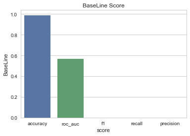

```python
import seaborn as sns
sns.set(style="whitegrid")
ax = sns.barplot(x="score", y="BaseLine", data=score)
ax.set_title('BaseLine Score')
```

## 2. UnderSampling 시각화

```
Text(0.5,1,'NearMiss1 Score')
```

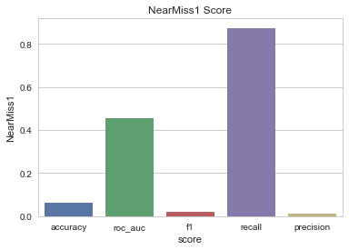

```python
import seaborn as sns
sns.set(style="whitegrid")
ax = sns.barplot(x="score", y="NearMiss1", data=score)
ax.set_title('NearMiss1 Score')
```

```
Text(0.5,1,'NearMiss2 Score')
```

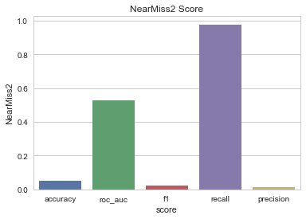

```python
import seaborn as sns
sns.set(style="whitegrid")
ax = sns.barplot(x="score", y="NearMiss2", data=score)
ax.set_title('NearMiss2 Score')
```

```
Text(0.5,1,'NearMiss3 Score')
```

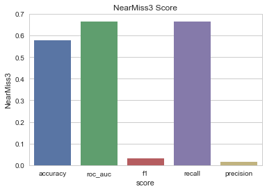

```python
import seaborn as sns
sns.set(style="whitegrid")
ax = sns.barplot(x="score", y="NearMiss3", data=score)
ax.set_title('NearMiss3 Score')
```

```
Text(0.5,1,'RandomUnderSampler')
```

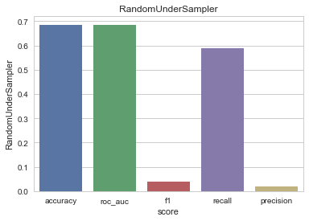

```python
import seaborn as sns
sns.set(style="whitegrid")
ax = sns.barplot(x="score", y="RandomUnderSampler", data=score)
ax.set_title('RandomUnderSampler')
```

```
Text(0.5,1,'CNN')
```

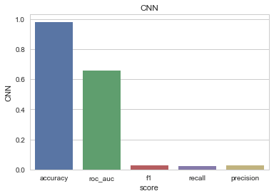

```python
import seaborn as sns
sns.set(style="whitegrid")
ax = sns.barplot(x="score", y="CNN", data=score)
ax.set_title('CNN')
```

```
Text(0.5,1,'ENN')
```

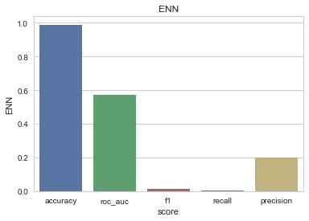

```python
import seaborn as sns
sns.set(style="whitegrid")
ax = sns.barplot(x="score", y="ENN", data=score)
ax.set_title('ENN')
```

```
Text(0.5,1,'Repeated_edites_nearest_neighbor Score')
```

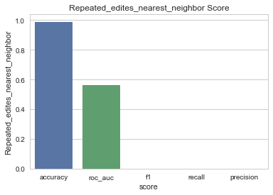

```python
import seaborn as sns
sns.set(style="whitegrid")
ax = sns.barplot(x="score", y="Repeated_edites_nearest_neighbor", data=score)
ax.set_title('Repeated_edites_nearest_neighbor Score')
```

```
Text(0.5,1,'Tomek_Link_Removal Score')
```

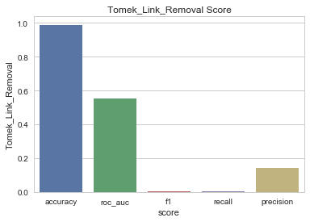

```python
import seaborn as sns
sns.set(style="whitegrid")
ax = sns.barplot(x="score", y="Tomek_Link_Removal", data=score)
ax.set_title('Tomek_Link_Removal Score')
```

## OverSampling 시각화

```
Text(0.5,1,'Random_Oversampling_of_minority_class Score')
```

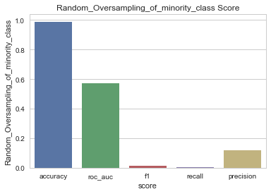

```python
import seaborn as sns
sns.set(style="whitegrid")
ax = sns.barplot(x="score", y="Random_Oversampling_of_minority_class", data=score)
ax.set_title('Random_Oversampling_of_minority_class Score')
```

```
Text(0.5,1,'SMOTE Score')
```

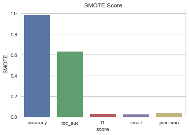

```python
import seaborn as sns
sns.set(style="whitegrid")
ax = sns.barplot(x="score", y="SMOTE", data=score)
ax.set_title('SMOTE Score')
```

```
Text(0.5,1,'SMOTE1 Score')
```

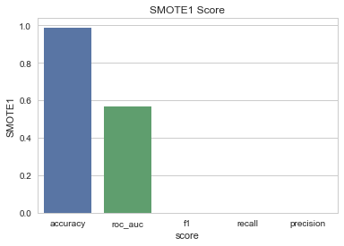

```python
import seaborn as sns
sns.set(style="whitegrid")
ax = sns.barplot(x="score", y="SMOTE1", data=score)
ax.set_title('SMOTE1 Score')
```

```
Text(0.5,1,'SMOTE2 Score')
```

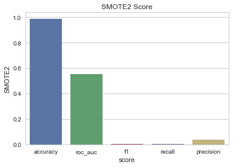

```python
import seaborn as sns
sns.set(style="whitegrid")
ax = sns.barplot(x="score", y="SMOTE2", data=score)
ax.set_title('SMOTE2 Score')
```

```
Text(0.5,1,'SMOTE+TOMEK Score')
```

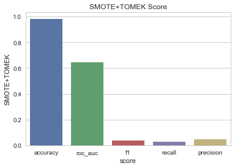

```python
import seaborn as sns
sns.set(style="whitegrid")
ax = sns.barplot(x="score", y="SMOTE+TOMEK", data=score)
ax.set_title('SMOTE+TOMEK Score')
```

```
Text(0.5,1,'SMOTE+ENN Score')
```

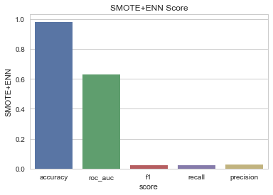

```python
import seaborn as sns
sns.set(style="whitegrid")
ax = sns.barplot(x="score", y="SMOTE+ENN", data=score)
ax.set_title('SMOTE+ENN Score')
```

## 3. Ensemble 시각화

```
Text(0.5,1,'EasyEnsemble Score')
```

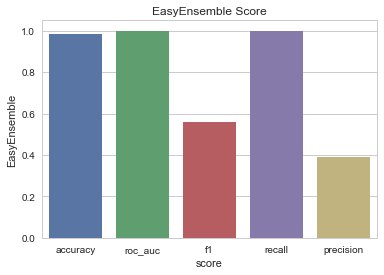

```python
import seaborn as sns
sns.set(style="whitegrid")
ax = sns.barplot(x="score", y="EasyEnsemble", data=score)
ax.set_title('EasyEnsemble Score')
```

```
(0.3, 1)
```

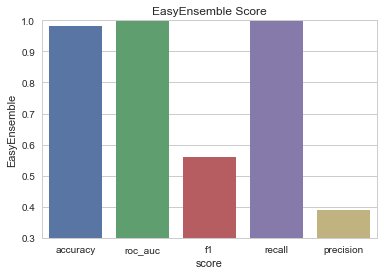

```python
# 다 너무 값이 높아서 확대함.
import seaborn as sns
sns.set(style="whitegrid")
ax = sns.barplot(x="score", y="EasyEnsemble", data=score)
ax.set_title('EasyEnsemble Score')
ax.set_ylim([0.3, 1])
```

```
Text(0.5,1,'BalanceCascade Score')
```

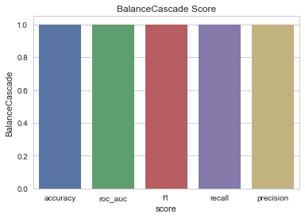

```python
import seaborn as sns
sns.set(style="whitegrid")
ax = sns.barplot(x="score", y="BalanceCascade", data=score)
ax.set_title('BalanceCascade Score')
```

```
(0.9985, 1)
```

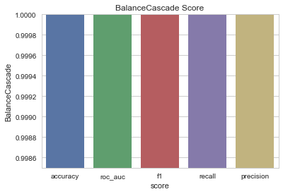

```python
# 다 너무 값이 높아서 확대함.
import seaborn as sns
sns.set(style="whitegrid")
ax = sns.barplot(x="score", y="BalanceCascade", data=score)
ax.set_title('BalanceCascade Score')
ax.set_ylim([0.9985, 1])
```

## 불균형(원본)데이터 & 모델 적용 후 데이터 recall & precision 값 비교

```python
score
```

|  | BaseLine | NearMiss1 | NearMiss2 | NearMiss3 | RandomUnderSampler | CNN | ENN | Repeated_edites_nearest_neighbor | Tomek_Link_Removal | Random_Oversampling_of_minority_class | SMOTE | SMOTE1 | SMOTE2 | SMOTE+TOMEK | SMOTE+ENN | EasyEnsemble | BalanceCascade | score |
| --- | --- | --- | --- | --- | --- | --- | --- | --- | --- | --- | --- | --- | --- | --- | --- | --- | --- | --- |
| accuracy | 0.988970 | 0.061171 | 0.049000 | 0.577509 | 0.685779 | 0.980730 | 0.988970 | 0.988748 | 0.989002 | 0.988748 | 0.983107 | 0.988527 | 0.988368 | 0.983043 | 0.981776 | 0.983043 | 1.0 | accuracy |
| roc_auc | 0.565478 | 0.456500 | 0.526399 | 0.665281 | 0.684391 | 0.657161 | 0.571963 | 0.563585 | 0.551534 | 0.570502 | 0.631077 | 0.567817 | 0.554608 | 0.646806 | 0.627780 | 0.999712 | 1.0 | roc_auc |
| f1 | 0.000000 | 0.019789 | 0.021778 | 0.032937 | 0.038969 | 0.025641 | 0.011364 | 0.000000 | 0.005731 | 0.011142 | 0.029144 | 0.000000 | 0.005420 | 0.036036 | 0.023769 | 0.561116 | 1.0 | f1 |
| recall | 0.000000 | 0.874269 | 0.976608 | 0.663743 | 0.587719 | 0.023392 | 0.005848 | 0.000000 | 0.002924 | 0.005848 | 0.023392 | 0.000000 | 0.002924 | 0.029240 | 0.020468 | 1.000000 | 1.0 | recall |
| precision | 0.000000 | 0.010008 | 0.011012 | 0.016887 | 0.020152 | 0.028369 | 0.200000 | 0.000000 | 0.142857 | 0.117647 | 0.038647 | 0.000000 | 0.037037 | 0.046948 | 0.028340 | 0.389966 | 1.0 | precision |

```python
score2 = score.loc[['recall','precision'],:]
score2
```

|  | BaseLine | NearMiss1 | NearMiss2 | NearMiss3 | RandomUnderSampler | CNN | ENN | Repeated_edites_nearest_neighbor | Tomek_Link_Removal | Random_Oversampling_of_minority_class | SMOTE | SMOTE1 | SMOTE2 | SMOTE+TOMEK | SMOTE+ENN | EasyEnsemble | BalanceCascade | score |
| --- | --- | --- | --- | --- | --- | --- | --- | --- | --- | --- | --- | --- | --- | --- | --- | --- | --- | --- |
| recall | 0.0 | 0.874269 | 0.976608 | 0.663743 | 0.587719 | 0.023392 | 0.005848 | 0.0 | 0.002924 | 0.005848 | 0.023392 | 0.0 | 0.002924 | 0.029240 | 0.020468 | 1.000000 | 1.0 | recall |
| precision | 0.0 | 0.010008 | 0.011012 | 0.016887 | 0.020152 | 0.028369 | 0.200000 | 0.0 | 0.142857 | 0.117647 | 0.038647 | 0.0 | 0.037037 | 0.046948 | 0.028340 | 0.389966 | 1.0 | precision |

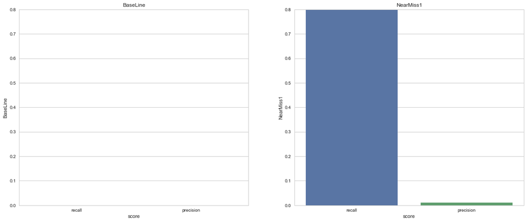

```python
f, ax = plt.subplots(1, 2, figsize=(20,8))
sns.barplot(x="score", y="BaseLine", data=score2, ax=ax[0])
ax[0].set_title('BaseLine')
ax[0].set_ylim([0, 0.8])
sns.barplot(x="score", y="NearMiss1", data=score2, ax=ax[1])
ax[1].set_title('NearMiss1')
ax[1].set_ylim([0, 0.8])
plt.show()
```

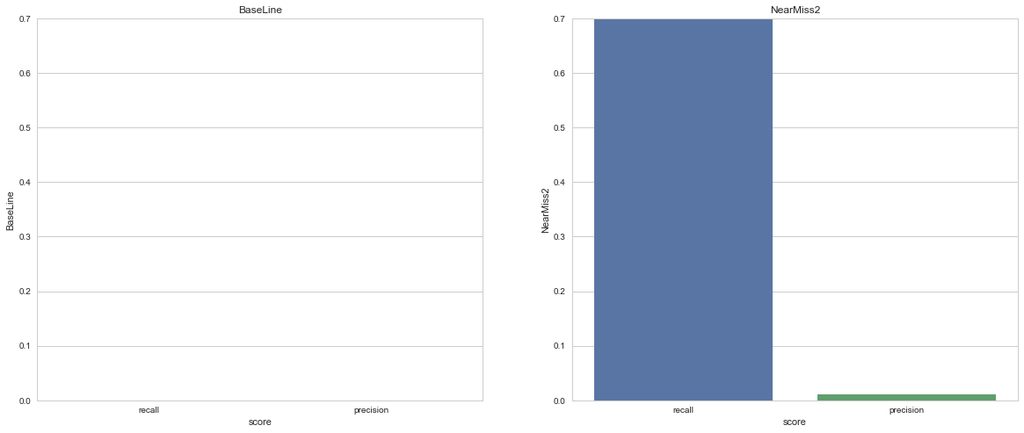

```python
f, ax = plt.subplots(1, 2, figsize=(20,8))
sns.barplot(x="score", y="BaseLine", data=score2, ax=ax[0])
ax[0].set_title('BaseLine')
ax[0].set_ylim([0, 0.7])
sns.barplot(x="score", y="NearMiss2", data=score2, ax=ax[1])
ax[1].set_title('NearMiss2')
ax[1].set_ylim([0, 0.7])
plt.show()
```

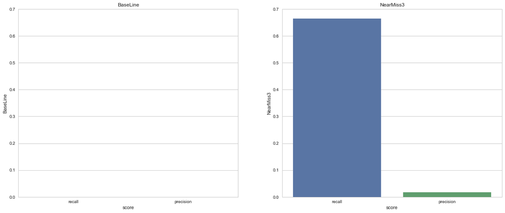

```python
f, ax = plt.subplots(1, 2, figsize=(20,8))
sns.barplot(x="score", y="BaseLine", data=score2, ax=ax[0])
ax[0].set_title('BaseLine')
ax[0].set_ylim([0, 0.7])
sns.barplot(x="score", y="NearMiss3", data=score2, ax=ax[1])
ax[1].set_title('NearMiss3')
ax[1].set_ylim([0, 0.7])
plt.show()
```

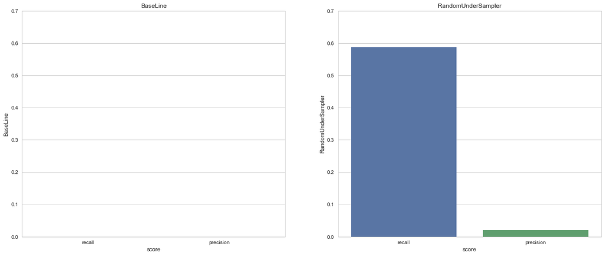

```python
f, ax = plt.subplots(1, 2, figsize=(20,8))
sns.barplot(x="score", y="BaseLine", data=score2, ax=ax[0])
ax[0].set_title('BaseLine')
ax[0].set_ylim([0, 0.7])
sns.barplot(x="score", y="RandomUnderSampler", data=score2, ax=ax[1])
ax[1].set_title('RandomUnderSampler')
ax[1].set_ylim([0, 0.7])
plt.show()
```

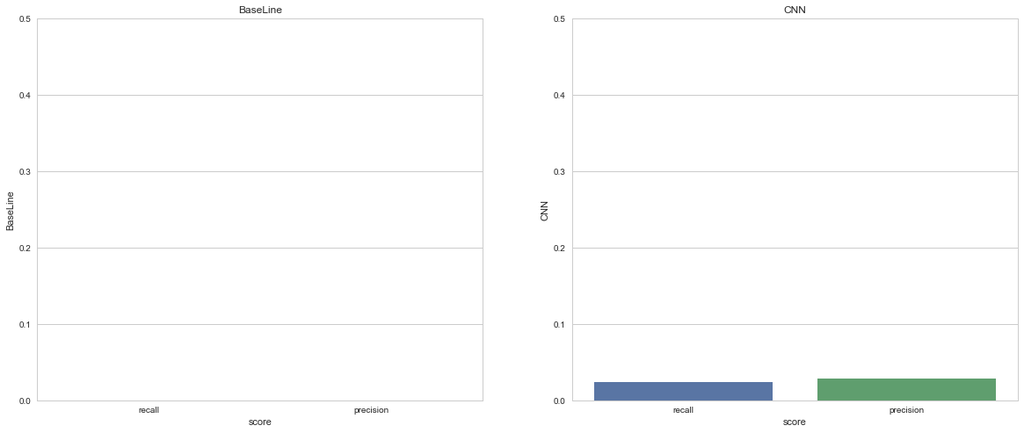

```python
f, ax = plt.subplots(1, 2, figsize=(20,8))
sns.barplot(x="score", y="BaseLine", data=score2, ax=ax[0])
ax[0].set_title('BaseLine')
ax[0].set_ylim([0, 0.5])
sns.barplot(x="score", y="CNN", data=score2, ax=ax[1])
ax[1].set_title('CNN')
ax[1].set_ylim([0, 0.5])
plt.show()
```

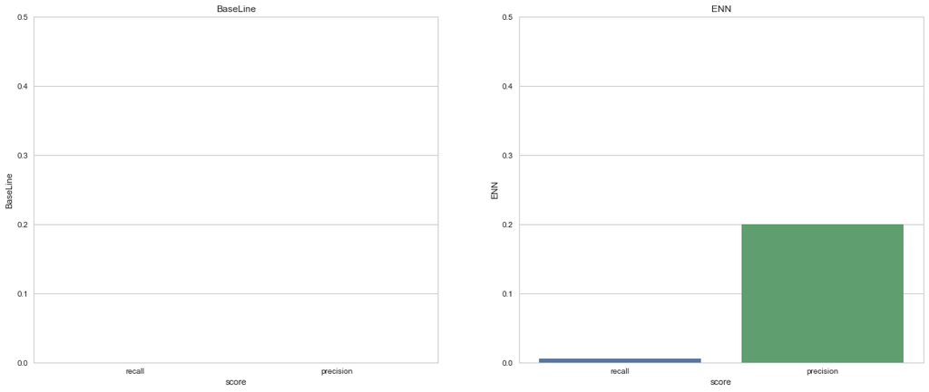

```python
f, ax = plt.subplots(1, 2, figsize=(20,8))
sns.barplot(x="score", y="BaseLine", data=score2, ax=ax[0])
ax[0].set_title('BaseLine')
ax[0].set_ylim([0, 0.5])
sns.barplot(x="score", y="ENN", data=score2, ax=ax[1])
ax[1].set_title('ENN')
ax[1].set_ylim([0, 0.5])
plt.show()
```

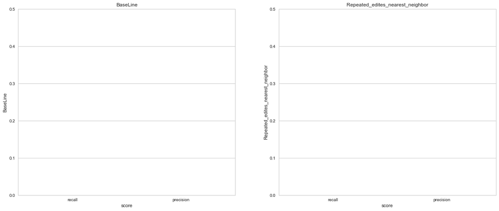

```python
f, ax = plt.subplots(1, 2, figsize=(20,8))
sns.barplot(x="score", y="BaseLine", data=score2, ax=ax[0])
ax[0].set_title('BaseLine')
ax[0].set_ylim([0, 0.5])
sns.barplot(x="score", y="Repeated_edites_nearest_neighbor", data=score2, ax=ax[1])
ax[1].set_title('Repeated_edites_nearest_neighbor')
ax[1].set_ylim([0, 0.5])
plt.show()
```

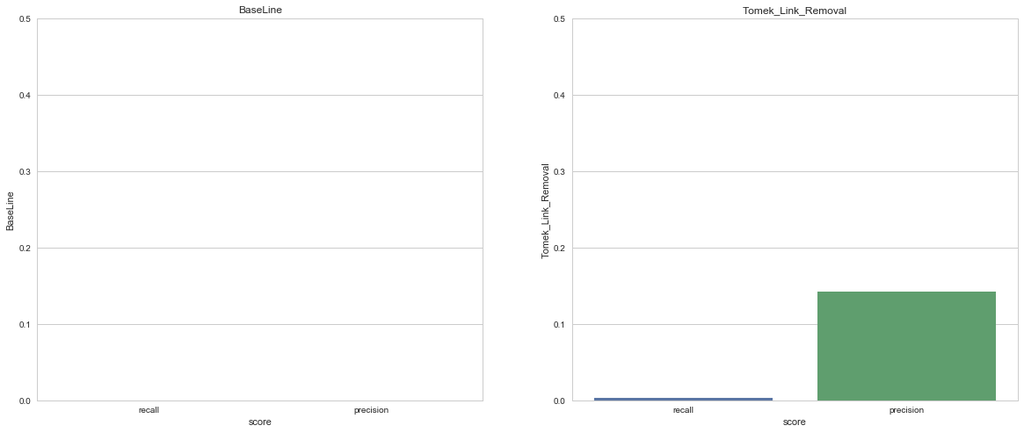

```python
f, ax = plt.subplots(1, 2, figsize=(20,8))
sns.barplot(x="score", y="BaseLine", data=score2, ax=ax[0])
ax[0].set_title('BaseLine')
ax[0].set_ylim([0, 0.5])
sns.barplot(x="score", y="Tomek_Link_Removal", data=score2, ax=ax[1])
ax[1].set_title('Tomek_Link_Removal')
ax[1].set_ylim([0, 0.5])
plt.show()
```

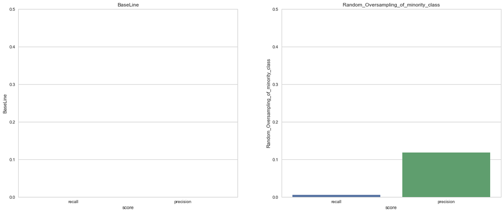

```python
f, ax = plt.subplots(1, 2, figsize=(20,8))
sns.barplot(x="score", y="BaseLine", data=score2, ax=ax[0])
ax[0].set_title('BaseLine')
ax[0].set_ylim([0, 0.5])
sns.barplot(x="score", y="Random_Oversampling_of_minority_class", data=score2, ax=ax[1])
ax[1].set_title('Random_Oversampling_of_minority_class')
ax[1].set_ylim([0, 0.5])
plt.show()
```

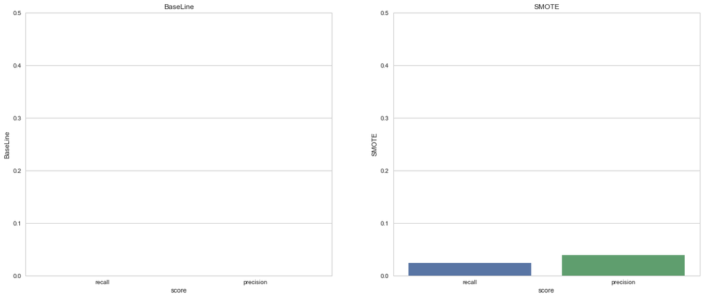

```python
f, ax = plt.subplots(1, 2, figsize=(20,8))
sns.barplot(x="score", y="BaseLine", data=score2, ax=ax[0])
ax[0].set_title('BaseLine')
ax[0].set_ylim([0, 0.5])
sns.barplot(x="score", y="SMOTE", data=score2, ax=ax[1])
ax[1].set_title('SMOTE')
ax[1].set_ylim([0, 0.5])
plt.show()
```